# A Tufte Handout Example

## Step 4 : Compute the Eigenvalues and Eigenvectors of the covariance matrix.

This is done to identify the principle components.

Eigenvectors and eigenvalues are the linear algebra concepts that we need to compute from the covariance matrix in order to determine the principal components of the data. Before getting to the explanation of these concepts, let’s first understand what do we mean by principal components.

Principal components are new variables that are constructed as linear combinations or mixtures of the initial variables. These combinations are done in such a way that the new variables (i.e., principal components) are uncorrelated and most of the information within the initial variables is squeezed or compressed into the first components. So, the idea is 10-dimensional data gives you 10 principal components, but PCA tries to put maximum possible information in the first component, then maximum remaining information in the second and so on, until having something like shown in the scree plot below.

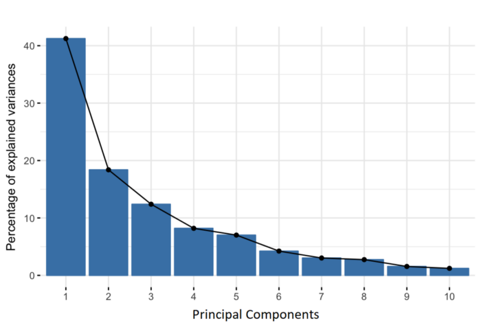

Geometrically speaking, principal components represent the directions of the data that explain a maximal amount of variance, that is to say, the lines that capture most information of the data. The relationship between variance and information here, is that, the larger the variance carried by a line, the larger the dispersion of the data points along it, and the larger the dispersion along a line, the more information it has. To put all this simply, just think of principal components as new axes that provide the best angle to see and evaluate the data, so that the differences between the observations are better visible.

## How does Principle Component Work

The second principal component is calculated in the same way, with the condition that it is uncorrelated with (i.e., perpendicular to) the first principal component and that it accounts for the next highest variance.

This continues until a total of p principal components have been calculated, equal to the original number of variables.

Now that we understand what we mean by principal components, let’s go back to eigenvectors and eigenvalues. What you first need to know about them is that they always come in pairs, so that every eigenvector has an eigenvalue. And their number is equal to the number of dimensions of the data. For example, for a 3-dimensional data set, there are 3 variables, therefore there are 3 eigenvectors with 3 corresponding eigenvalues.

Without further ado, it is eigenvectors and eigenvalues who are behind all the magic explained above, because the eigenvectors of the Covariance matrix are actually the directions of the axes where there is the most variance(most information) and that we call Principal Components. And eigenvalues are simply the coefficients attached to eigenvectors, which give the amount of variance carried in each Principal Component.

By ranking your eigenvectors in order of their eigenvalues, highest to lowest, you get the principal components in order of significance.

Without further ado, it is eigenvectors and eigenvalues who are behind all the magic explained above, because the eigenvectors of the Covariance matrix are actually the directions of the axes where there is the most variance(most information) and that we call Principal Components. And eigenvalues are simply the coefficients attached to eigenvectors, which give the amount of variance carried in each Principal Component.

By ranking your eigenvectors in order of their eigenvalues, highest to lowest, you get the principal components in order of significance.

Let’s suppose that our data set is 2-dimensional with 2 variables x,y and that the eigenvectors and eigenvalues of the covariance matrix are as follows:

$v_1 = \begin{bmatrix} 0.6778736 \\0. 7351785 \end{bmatrix}$ and $\lambda_1 = 1.284028$, and ;

$v_2 = \begin{bmatrix} -0. 7351785 \\ 0.6778736\end{bmatrix}$ and $\lambda_1 = 0.04908323$

If we rank the eigenvalues in descending order, we get $\lambda_1>\lambda_2$, which means that the eigenvector that corresponds to the first principal component (PC1) is v1 and the one that corresponds to the second component (PC2) is v2.

After having the principal components, to compute the percentage of variance (information) accounted for by each component, we divide the eigenvalue of each component by the sum of eigenvalues. If we apply this on the example above, we find that PC1 and PC2 carry respectively 96% and 4% of the variance of the data.

## Step 4 : Feature Selection

As we saw in the previous step, computing the eigenvectors and ordering them by their eigenvalues in descending order, allow us to find the principal components in order of significance. In this step, what we do is, to choose whether to keep all these components or discard those of lesser significance (of low eigenvalues), and form with the remaining ones a matrix of vectors that we call Feature vector.

So, the feature vector is simply a matrix that has as columns the eigenvectors of the components that we decide to keep. This makes it the first step towards dimensionality reduction, because if we choose to keep only p eigenvectors (components) out of n, the final data set will have only p dimensions.

Continuing with the example from the previous step, we can either form a feature vector with both of the eigenvectors v1 and v2:

$$\begin{bmatrix}0.6778736 & -0.
7351785\\
0.7351785&0.6778736\end{bmatrix}$$

Or discard the eigenvector v2, which is the one of lesser significance, and form a feature vector with v1 only:

$$\begin{bmatrix}0.6778736
\\0.7351785\end{bmatrix}$$

Discarding the eigenvector v2 will reduce dimensionality by 1, and will consequently cause a loss of information in the final data set. But given that v2 was carrying only 4% of the information, the loss will be therefore not important and we will still have 96% of the information that is carried by v1.

So, as we saw in the example, it’s up to you to choose whether to keep all the components or discard the ones of lesser significance, depending on what you are looking for. Because if you just want to describe your data in terms of new variables (principal components) that are uncorrelated without seeking to reduce dimensionality, leaving out lesser significant components is not needed.

## Last Step : Recast the Data Along the Principal Component Axes

In the previous steps, apart from standardization, you do not make any changes on the data, you just select the principal components and form the feature vector, but the input data set remains always in terms of the original axes (i.e, in terms of the initial variables).

In this step, which is the last one, the aim is to use the feature vector formed using the eigenvectors of the covariance matrix, to reorient the data from the original axes to the ones represented by the principal components (hence the name Principal Components Analysis). This can be done by multiplying the transpose of the original data set by the transpose of the feature vector.

```
\[FinalDataset = FeatureVector^T \times StandardizedOriginalDataset^T\]
```

PCA works best for numerical data. To demonstrate this, let’s do this for the mtcars data set, as follows;

```r
data("mtcars")
head(mtcars)
```

```
##                    mpg cyl disp  hp drat    wt  qsec vs am gear carb
## Mazda RX4         21.0   6  160 110 3.90 2.620 16.46  0  1    4    4
## Mazda RX4 Wag     21.0   6  160 110 3.90 2.875 17.02  0  1    4    4
## Datsun 710        22.8   4  108  93 3.85 2.320 18.61  1  1    4    1
## Hornet 4 Drive    21.4   6  258 110 3.08 3.215 19.44  1  0    3    1
## Hornet Sportabout 18.7   8  360 175 3.15 3.440 17.02  0  0    3    2
## Valiant           18.1   6  225 105 2.76 3.460 20.22  1  0    3    1
```

As I have mentioned above, the PCA does not work well for categorical data thus let’s eliminate vs and am as follows;

```r
mtcars2 <- mtcars |>
  dplyr::select(,-c("vs", "am"))
```

Thus the data is;

```r
dplyr::glimpse(mtcars2)
```

```
## Rows: 32
## Columns: 9
## $ mpg  <dbl> 21.0, 21.0, 22.8, 21.4, 18.7, 18.1, 14.3, 24.4, 22.8, 19.2, 17.8,…
## $ cyl  <dbl> 6, 6, 4, 6, 8, 6, 8, 4, 4, 6, 6, 8, 8, 8, 8, 8, 8, 4, 4, 4, 4, 8,…
## $ disp <dbl> 160.0, 160.0, 108.0, 258.0, 360.0, 225.0, 360.0, 146.7, 140.8, 16…
## $ hp   <dbl> 110, 110, 93, 110, 175, 105, 245, 62, 95, 123, 123, 180, 180, 180…
## $ drat <dbl> 3.90, 3.90, 3.85, 3.08, 3.15, 2.76, 3.21, 3.69, 3.92, 3.92, 3.92,…
## $ wt   <dbl> 2.620, 2.875, 2.320, 3.215, 3.440, 3.460, 3.570, 3.190, 3.150, 3.…
## $ qsec <dbl> 16.46, 17.02, 18.61, 19.44, 17.02, 20.22, 15.84, 20.00, 22.90, 18…
## $ gear <dbl> 4, 4, 4, 3, 3, 3, 3, 4, 4, 4, 4, 3, 3, 3, 3, 3, 3, 4, 4, 4, 3, 3,…
## $ carb <dbl> 4, 4, 1, 1, 2, 1, 4, 2, 2, 4, 4, 3, 3, 3, 4, 4, 4, 1, 2, 1, 1, 2,…
```

All variables in our data set are continuous variables hence we can proceed with the PCA. In R, PCA is done using the base function **prcomp()** as follows;

```r
mtcars.pc <- prcomp(mtcars2, center = TRUE, scale. = TRUE)
```

The scale function is used for normalization. Then the Principal Components are;

```r
summary(mtcars.pc)
```

```
## Importance of components:
##                           PC1    PC2     PC3     PC4     PC5     PC6     PC7
## Standard deviation     2.3782 1.4429 0.71008 0.51481 0.42797 0.35184 0.32413
## Proportion of Variance 0.6284 0.2313 0.05602 0.02945 0.02035 0.01375 0.01167
## Cumulative Proportion  0.6284 0.8598 0.91581 0.94525 0.96560 0.97936 0.99103
##                           PC8     PC9
## Standard deviation     0.2419 0.14896
## Proportion of Variance 0.0065 0.00247
## Cumulative Proportion  0.9975 1.00000
```

Thus as can be seen above, our PC1 holds 62.84% of the information and PC2 IS 23.13% all the way to PC9. These are the Principal Components.

## Plotting the PCA

To plot the PCA, we need the package ggbiplot which will helps us to plot the biplot which includes both the position of each sample in terms of PC1 and PC2 and also will show us how the initial variables map onto this. . A biplot is a type of plot that will allow you to visualize how the samples relate to one another in our PCA (which samples are similar and which are different) and will simultaneously reveal how each variable contributes to each principal component.

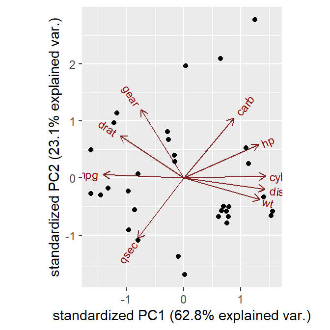

A biplot of the principle component analysis

```r
library(ggbiplot)
ggbiplot(mtcars.pc)
```

The axes are seen as arrows originating from the center point. Here, you see that the variables hp, cyl, and disp all contribute to PC1, with higher values in those variables moving the samples to the right on this plot. This lets you see how the data points relate to the axes, but it’s not very informative without knowing which point corresponds to which sample (car).

You’ll provide an argument to ggbiplot: let’s give it the rownames of mtcars as labels. This will name each point with the name of the car in question:

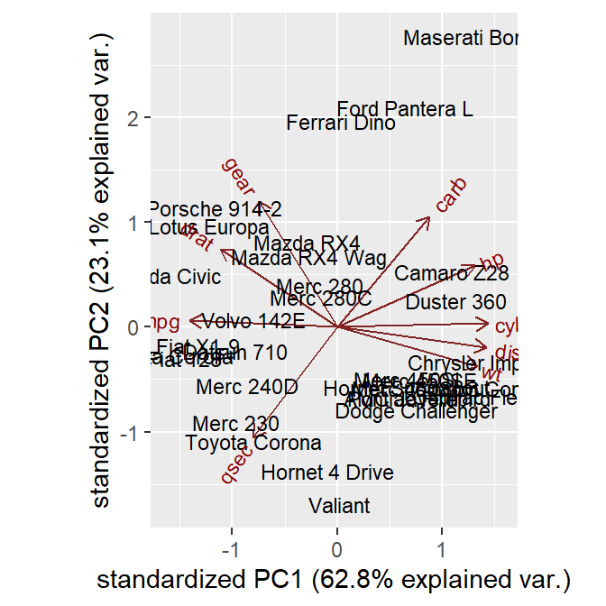

```r
ggbiplot(mtcars.pc, labels=rownames(mtcars2))
```

Now you can see which cars are similar to one another. For example, the Maserati Bora, Ferrari Dino and Ford Pant era L all cluster together at the top. This makes sense, as all of these are sports cars.

# Correspondence Analysis (CA)

let’s load the packages

```r
library("FactoMineR")
library("factoextra")
```

The data should be a contingency table. We’ll use the demo data sets housetasks available in the factoextra R package.

```r
data("housetasks")
housetasks
```

```
##            Wife Alternating Husband Jointly
## Laundry     156          14       2       4
## Main_meal   124          20       5       4
## Dinner       77          11       7      13
## Breakfeast   82          36      15       7
## Tidying      53          11       1      57
## Dishes       32          24       4      53
## Shopping     33          23       9      55
## Official     12          46      23      15
## Driving      10          51      75       3
## Finances     13          13      21      66
## Insurance     8           1      53      77
## Repairs       0           3     160       2
## Holidays      0           1       6     153
```

The data is a contingency table containing 13 housetasks and their repartition in the couple: rows are the different tasks values are the frequencies of the tasks done : - by the wife only

- alternatively
- by the husband only
- or jointly

The above contingency table is not very large. Therefore, it’s easy to visually inspect and interpret row and column profiles:

It’s evident that, the housetasks

- Laundry, Main_Meal and Dinner are more frequently done by the “Wife”.
- Repairs and driving are dominantly done by the husband
- Holidays are frequently associated with the column “jointly”

Briefly, contingency table can be visualized using the functions *balloonplot()* from **gplots package** and *mosaicplot()* from **garphics package**

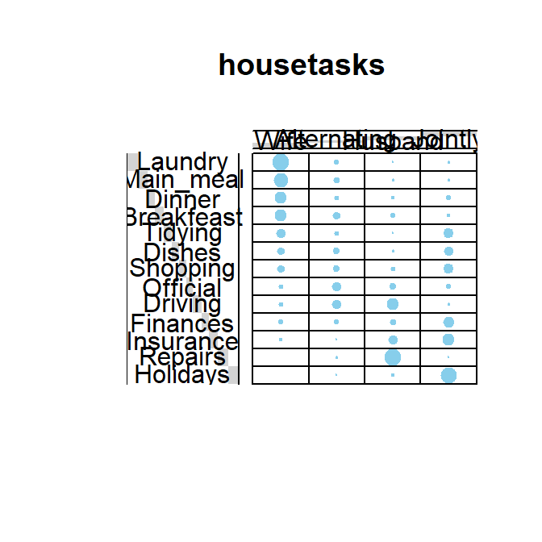

```r
library(gplots)
# 1. convert the data as a table
dt <- as.table(as.matrix(housetasks))
# 2. Graph
balloonplot(t(dt), main ="housetasks", xlab ="", ylab="",
            label = FALSE, show.margins = FALSE)
```

After the visualization, we can now conduct CA analysis as follows;

```r
library("FactoMineR")
res.ca <- CA(housetasks, graph = FALSE)
```

To identify which variables have high amount of information, we can use the spree plot which can be constructed using the function *fvix_eg()* in the **factoextra** package, as follows;

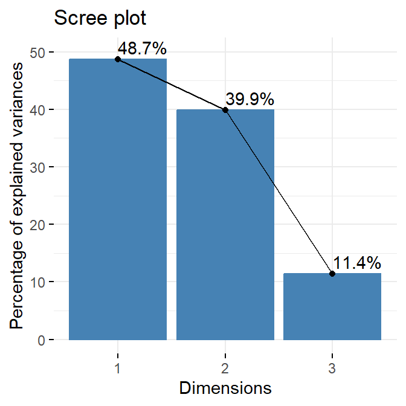

```r
library(factoextra)
fviz_eig(res.ca, addlabels = TRUE, ylim = c(0,50))
```

The point at which the scree plot shows a bend (so called “elbow”) can be considered as indicating an optimal dimensionality. It’s also possible to calculate an average eigenvalue above which the axis should be kept in the solution. Our data contains 13 rows and 4 columns.

- If the data were random, the expected value of the eigenvalue for each axis would be 1/(nrow(housetasks)-1) = 1/12 = 8.33% in terms of rows.
- Likewise, the average axis should account for 1/(ncol(housetasks)-1) = 1/3 = 33.33% in terms of the 4 columns.

According to (M. T. Bendixen 1995):

Any axis with a contribution larger than the maximum of these two percentages should be considered as important and included in the solution for the interpretation of the data.

The R code below, draws the scree plot with a red dashed line specifying the average eigenvalue:

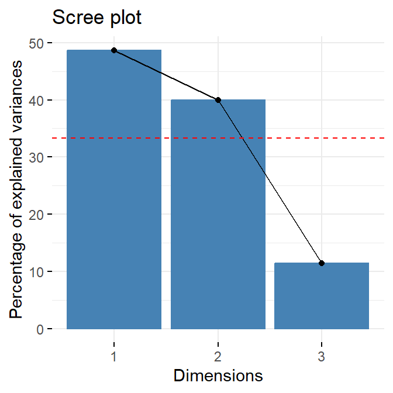

```r
library(ggplot2)
fviz_screeplot(res.ca) +
 geom_hline(yintercept=33.33, linetype=2, color="red")
```

According to the graph above, only dimensions 1 and 2 should be used in the solution. The dimension 3 explains only 11.4% of the total inertia which is below the average eigeinvalue (33.33%) and too little to be kept for further analysis.

The function *fviz_ca_biplot()* from **factoextra package** can be used to draw the biplot of rows and columns variables.

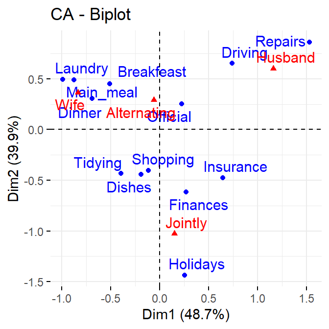

```r
fviz_ca_biplot(res.ca, repel = TRUE)
```

The function get_ca_col() [in factoextra] is used to extract the results for column variables. This function returns a list containing the coordinates, the cos2, the contribution and the inertia of columns variables:

```r
col <- get_ca_col(res.ca)
```

# Multiple correspondence analysis (MCA)

We’ll use the demo data sets poison available in FactoMineR package:

```r
data("poison")
head(poison)
```

```
##   Age Time   Sick Sex   Nausea Vomiting Abdominals   Fever   Diarrhae   Potato
## 1   9   22 Sick_y   F Nausea_y  Vomit_n     Abdo_y Fever_y Diarrhea_y Potato_y
## 2   5    0 Sick_n   F Nausea_n  Vomit_n     Abdo_n Fever_n Diarrhea_n Potato_y
## 3   6   16 Sick_y   F Nausea_n  Vomit_y     Abdo_y Fever_y Diarrhea_y Potato_y
## 4   9    0 Sick_n   F Nausea_n  Vomit_n     Abdo_n Fever_n Diarrhea_n Potato_y
## 5   7   14 Sick_y   M Nausea_n  Vomit_y     Abdo_y Fever_y Diarrhea_y Potato_y
## 6  72    9 Sick_y   M Nausea_n  Vomit_n     Abdo_y Fever_y Diarrhea_y Potato_y
##     Fish   Mayo Courgette   Cheese   Icecream
## 1 Fish_y Mayo_y   Courg_y Cheese_y Icecream_y
## 2 Fish_y Mayo_y   Courg_y Cheese_n Icecream_y
## 3 Fish_y Mayo_y   Courg_y Cheese_y Icecream_y
## 4 Fish_y Mayo_n   Courg_y Cheese_y Icecream_y
## 5 Fish_y Mayo_y   Courg_y Cheese_y Icecream_y
## 6 Fish_n Mayo_y   Courg_y Cheese_y Icecream_y
```

This data is a result from a survey carried out on children of primary school who suffered from food poisoning. They were asked about their symptoms and about what they ate.

Subset only active individuals and variables for multiple correspondence analysis:

```r
poison.active <- poison[1:55, 5:15]
head(poison.active[, 1:6], 3)
```

```
##     Nausea Vomiting Abdominals   Fever   Diarrhae   Potato
## 1 Nausea_y  Vomit_n     Abdo_y Fever_y Diarrhea_y Potato_y
## 2 Nausea_n  Vomit_n     Abdo_n Fever_n Diarrhea_n Potato_y
## 3 Nausea_n  Vomit_y     Abdo_y Fever_y Diarrhea_y Potato_y
```

It’s also possible to plot the frequency of variable categories. The R code below, plots the first 4 columns:

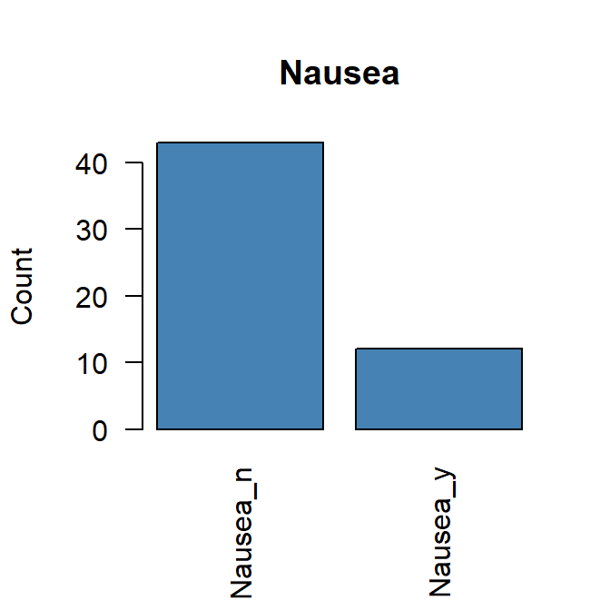

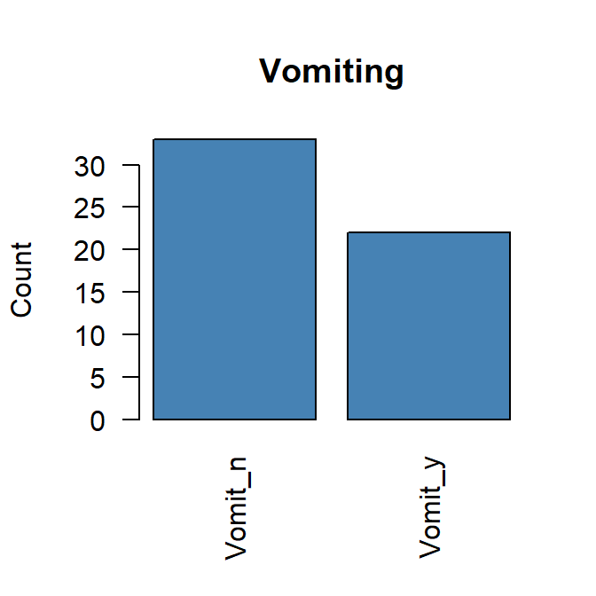

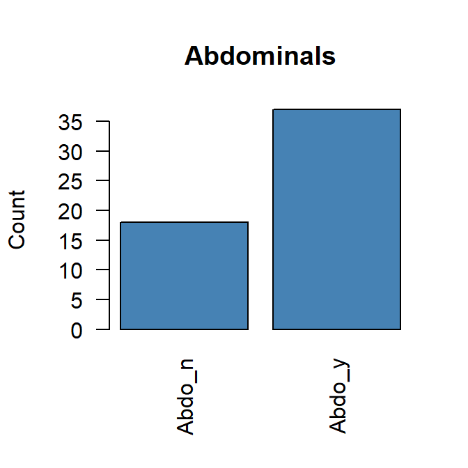

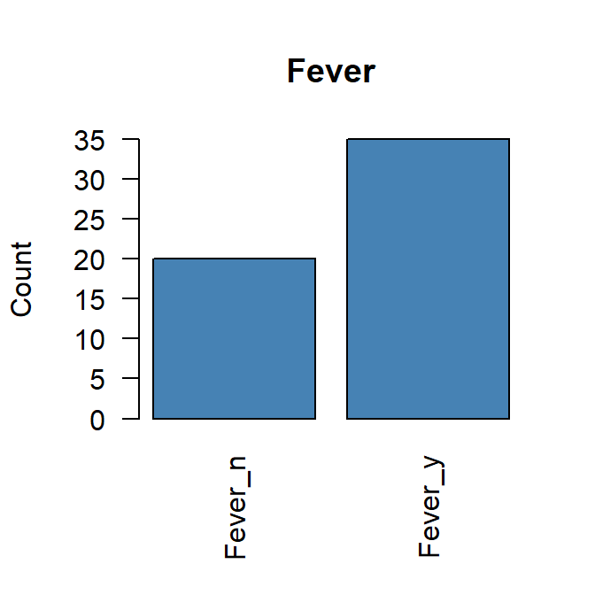

```r
for (i in 1:4) {
  plot(poison.active[,i], main=colnames(poison.active)[i],
       ylab = "Count", col="steelblue", las = 2)
  }
```

We can thus condcut MCA as follows;

```r
res.mca <- MCA(poison.active, graph = FALSE)
```

Let’s visualize the percentages of inertia explained by each MCA dimensions,

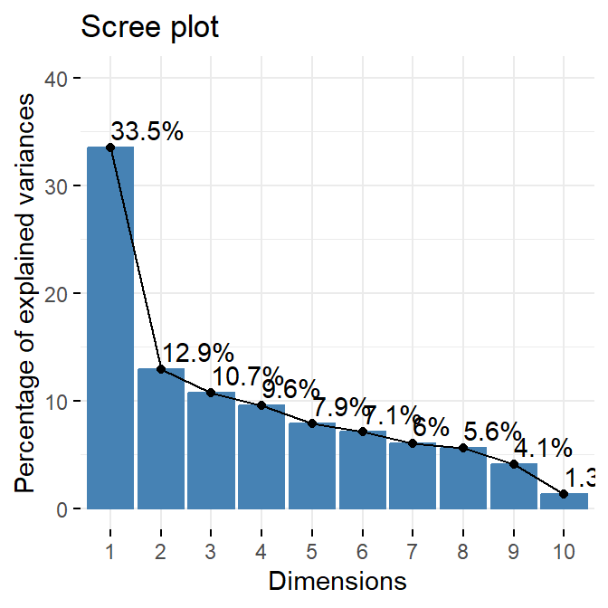

```r
fviz_screeplot(res.mca, addlabels = TRUE, ylim = c(0,40))
```

```r
var <- get_mca_var(res.mca)
head(round(var$coord, 2), 4)
```

```
##          Dim 1 Dim 2 Dim 3 Dim 4 Dim 5
## Nausea_n  0.27  0.12 -0.27  0.03  0.07
## Nausea_y -0.96 -0.43  0.95 -0.12 -0.26
## Vomit_n   0.48 -0.41  0.08  0.27  0.05
## Vomit_y  -0.72  0.61 -0.13 -0.41 -0.08
```

# Factor analysis of mixed data (FAMD)

Factor analysis of mixed data (FAMD) is a principal component method dedicated to analyze a data set containing both quantitative and qualitative variables. t makes it possible to analyze the similarity between individuals by taking into account a mixed types of variables. Additionally, one can explore the association between all variables, both quantitative and qualitative variables. It can be seen as a combination of PCA and MCA.

We’ll use a subset of the wine data set available in FactoMineR package:

```r
data("wine")

# Subsetting the required columns
df <- wine[,c(1,2, 16, 22, 29, 28, 30,31)]
head(df[, 1:7], 4)
```

```
##           Label Soil Plante Acidity Harmony Intensity Overall.quality
## 2EL      Saumur Env1  2.000   2.107   3.143     2.857           3.393
## 1CHA     Saumur Env1  2.000   2.107   2.964     2.893           3.214
## 1FON Bourgueuil Env1  1.750   2.179   3.143     3.074           3.536
## 1VAU     Chinon Env2  2.304   3.179   2.038     2.462           2.464
```

The data contains 21 rows (wine, individuals) and 8 columns (attributes). The first two columns are categorical, that is label and Soil while the rest are numerical. The function *FAMD()* from **FactoMiner package** can be used to compute FAMD. A simplified format is :

*FAMD (base, ncp = 5, sup.var = NULL, ind.sup = NULL, graph = TRUE)*

- **base** : a data frame with n rows (individuals) and p columns (variables).
- **ncp** : the number of dimensions kept in the results (by default 5)
- **sup.var** : a vector indicating the indexes of the supplementary variables.
- **ind.sup** : a vector indicating the indexes of the supplementary individuals.
- **graph** : a logical value. If TRUE a graph is displayed.

```r
library(FactoMineR)
res.famd <- FAMD(df, graph = FALSE)
```

We’ll use the following factoextra functions:

- *get_eigenvalue(res.famd)*: Extract the eigenvalues/variances retained by each dimension (axis).
- *fviz_eig(res.famd)*: Visualize the eigenvalues/variances.
- *get_famd_ind(res.famd)*: Extract the results for individuals.
- *get_famd_var(res.famd)*: Extract the results for quantitative and qualitative variables.
- *fviz_famd_ind(res.famd)*, *fviz_famd_var(res.famd)* : Visualize the results for individuals and variables, respectively.

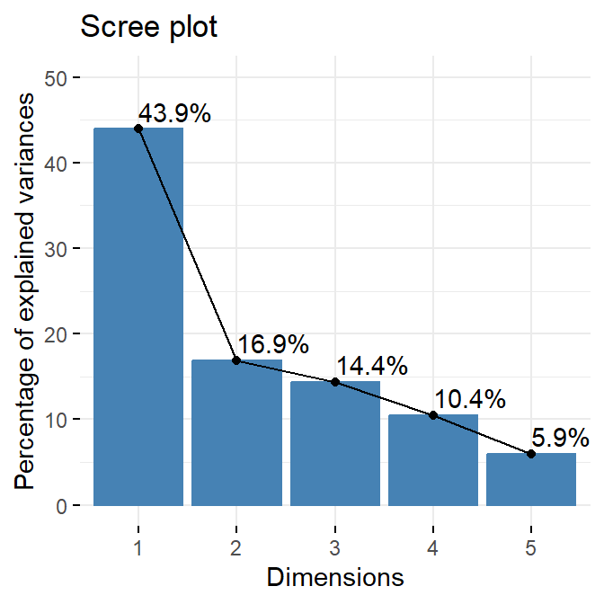

```r
fviz_screeplot(res.famd, addlabels = T, ylim = c(0, 50))
```

Then

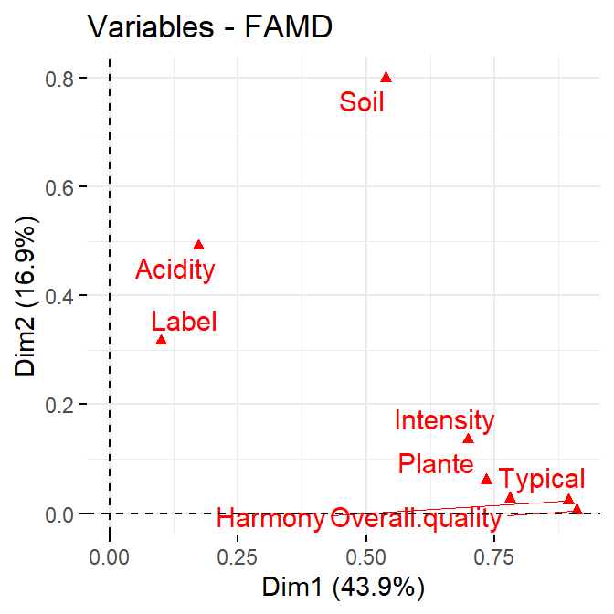

[figure not shown]

```r
# Plot of variables
fviz_famd_var(res.famd, repel = TRUE)
```

[figure not shown]

```r
# Contribution to the first dimension
fviz_contrib(res.famd, "var", axes = 1)
```

```r
# Contribution to the second dimension
fviz_contrib(res.famd, "var", axes = 2)
```

[output not shown]

The red dashed line on the graph above indicates the expected average value, If the contributions were uniform.